# Assignment 1 DMI

Tanner Garcia (tanneralexander.garcia01@estudiant.upf.edu) y David Fragoso (david.fragoso01@estudiant.upf.edu)

Last update: 15 March, 2026

This practical focuses on data wrangling, exploratory data analysis, visualization, and critical comparison with published results using real biomedical data.

We will work with the publication [**Proteomic and Metabolomic Characterization of COVID-19 Patient Sera**](https://www.sciencedirect.com/science/article/pii/S0092867420306279)

# Exercise 1

Download and load Supplementary Table 1 (“Additional Demographical and Baseline Characteristics of COVID-19 Patients and Control Groups”) from the supplementary materials of the publication.

## Exercise 1.1

Reproduce Table 1 from the manuscript using the supplementary data. Match the reported summary statistics as closely as possible.

Briefly discuss any discrepancies between your results and the published table, and provide possible explanations.

```r
#path <- "C:/Users/USUARIO/Desktop/CBEM/Data mining/Hands on I/Supplementary table 1.xlsx"

# use local path, assume in same folder
# makes more sense for submission
path <- "Supplementary table 1.xlsx"
data <- readxl::read_xlsx(path)
# summary(data)
```

```r
library(tableone)
library(boot)

data1 <- data
# Factor the basic variables that we're interested in
data1$`Sex - no.%` <-
  factor(data1$`Sex g`,
         levels=c(0,1),
         labels=c("Female", # Reference
                  "Male"))

# patient type. 0, healthy; 1, non-COVID-19; 2, non-Severe; 3, Severe
data1$`Group` <-
  factor(data1$`Group d`,
         levels=c(0,1,2,3),
         labels=c("Healthy Control", # Reference
                  "Non-COVID-19",
                  'Non-severe',
                  'Severe'))

data1$`BMI, kg/m2`<- as.numeric(data1$`BMI h`) # Converting BMI to numeric
data1$`COVID` <-
  factor(data1$`Group d`,
         levels=c(0,1,2,3),
         labels=c("", # Reference
                  "",
                  'COVID-19',
                  'COVID-19'))
# Add difference between onset and admission dates
data1$`Time from Onset to Admission, Days` <-
  as.numeric(difftime(data$`Admission date`,
                      data$`Onset date f`,
                      units = "days"))


table1::table1(~ `Sex - no.%` + `Age (year)` + `BMI, kg/m2` + `Time from Onset to Admission, Days`| COVID + `Group`,  overall=F, data=data1, topclass="Rtable1-zebra")
```

|  | Healthy Control (N=28) | Non-COVID-19 (N=25) | COVID-19 Non-severe (N=37) | COVID-19 Severe (N=28) |
| --- | --- | --- | --- | --- |
| Sex - no.% |  |  |  |  |
| Female | 7 (25.0%) | 8 (32.0%) | 14 (37.8%) | 12 (42.9%) |
| Male | 21 (75.0%) | 17 (68.0%) | 23 (62.2%) | 16 (57.1%) |
| Age (year) |  |  |  |  |
| Mean (SD) | 44.4 (8.26) | 49.2 (14.0) | 42.9 (12.5) | 54.8 (12.8) |
| Median [Min, Max] | 45.0 [28.0, 57.0] | 53.0 [23.0, 67.0] | 43.0 [18.0, 70.0] | 55.0 [30.0, 77.0] |
| BMI, kg/m2 |  |  |  |  |
| Mean (SD) | 24.4 (2.71) | 23.5 (2.68) | 24.5 (3.21) | 25.5 (2.52) |
| Median [Min, Max] | 24.2 [19.9, 32.9] | 24.7 [19.1, 27.4] | 24.2 [18.9, 30.7] | 24.9 [21.1, 31.3] |
| Missing | 0 (0%) | 5 (20.0%) | 0 (0%) | 3 (10.7%) |
| Time from Onset to Admission, Days |  |  |  |  |
| Mean (SD) | NA (NA) | NA (NA) | 3.59 (3.17) | 6.86 (5.17) |
| Median [Min, Max] | NA [NA, NA] | NA [NA, NA] | 3.00 [0, 14.0] | 7.50 [0, 23.0] |
| Missing | 28 (100%) | 25 (100%) | 0 (0%) | 0 (0%) |

Comparing both the table obtained and the one displayed by Shen et. al.(2020) we can first observe that many parameters that were not available to us like the *Time from Admission to Severe, Days, Symptoms - no. (%), Chest CT - no. (%), etc.*, are not present in our table. However we’ve been able to correctly capture the basic biological information of the patients that’s available in the dataset that they have uploaded and, on top of that, we’ve managed to replicate the style of display of severity groups and the biological parameters of the patients with a decent grade of fidelity.

## Exercise 1.2

Perform an exploratory data analysis (EDA) of the dataset. At a minimum, include:

- Descriptive statistics for key variables
- Appropriate visualizations (e.g. distributions, group comparisons)
- A brief written summary of notable patterns, anomalies, or data quality issues

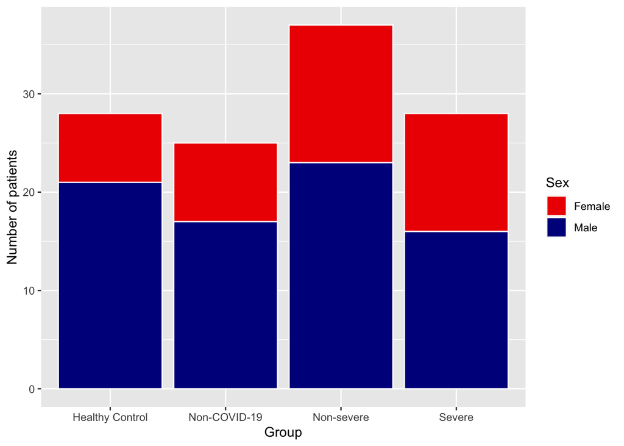

```r
library(ggplot2)

# Plotting the distributions for different characteristics of the patients
## Starting with the different COVID-19 groups divided by the sex

ggplot(data1, aes(x = Group, fill = `Sex - no.%`)) +
  geom_bar( color = 'white') +
  scale_fill_manual(values = c("Male" = "blue4", "Female" = "red2")) +
  labs(
    y = "Number of patients",
    fill = "Sex")
```

```r
# Exploring the distribution of the age in years within each group:

library(dplyr)
```

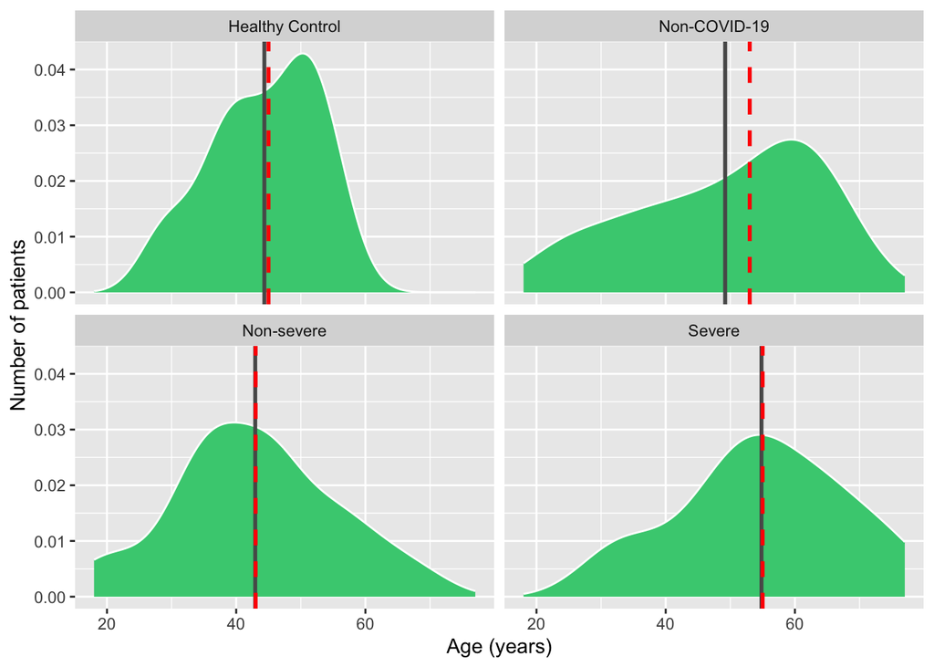

```r
stats <- data1 %>%
  group_by(Group) %>%
  summarise(
    mean_age   = mean(`Age (year)`, na.rm = TRUE),
    median_age = median(`Age (year)`, na.rm = TRUE)
  )
ggplot(data1, aes(x = `Age (year)`)) +
  geom_density(fill = "seagreen3", color = "white") +
  facet_wrap(~ Group) +
  geom_vline(
    data = stats,
    aes(xintercept = mean_age),
    color = "gray35",
    linewidth = 1
  ) +
  geom_vline(
    data = stats,
    aes(xintercept = median_age),
    color = "red",
    linetype = "dashed",
    linewidth = 1
  ) +
  ylab("Number of patients") +
  xlab("Age (years)")
```

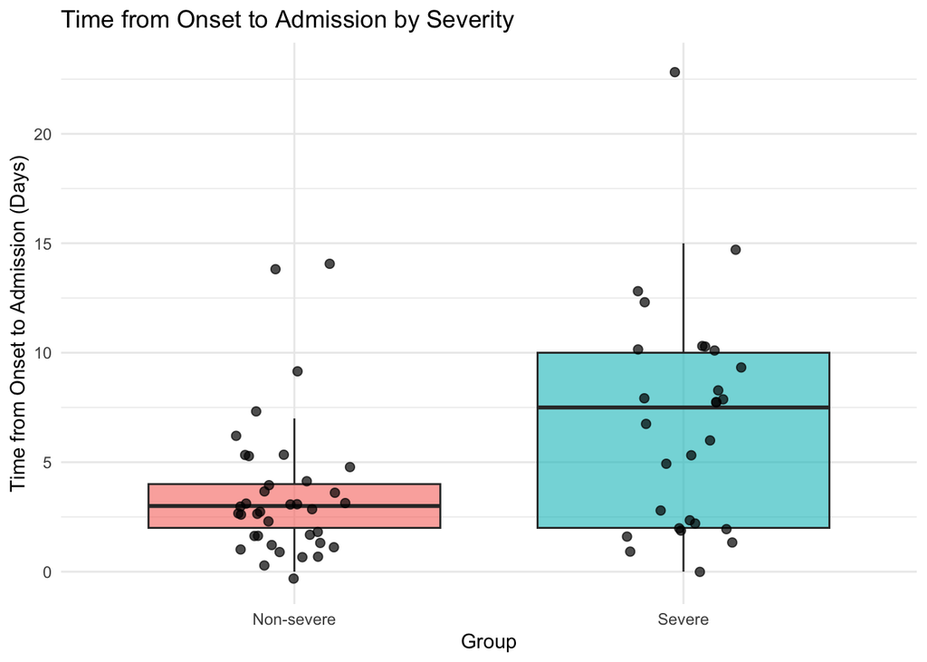

```r
# Load libraries
library(ggplot2)
library(dplyr)

# Ensure Group is a factor
data2 <- data1
data2 <- data2[data2$Group %in% c("Severe", "Non-severe"), ]

# Plot
ggplot(data2, aes(x = Group, y = `Time from Onset to Admission, Days`, fill = Group)) +
  geom_boxplot(alpha = 0.6, outlier.shape = NA) +
  geom_jitter(width = 0.15, size = 2, alpha = 0.7) +
  labs(
    title = "Time from Onset to Admission by Severity",
    x = "Group",
    y = "Time from Onset to Admission (Days)"
  ) +
  theme_minimal() +
  theme(legend.position = "none")
```

# Exercise 2

## Exercise 2.1

Reproduce Supplementary Figure 1 using the data without modifying or removing any observations. Use the same variables and groupings as in the original figure.

```r
data <- readxl::read_xlsx(path)
```

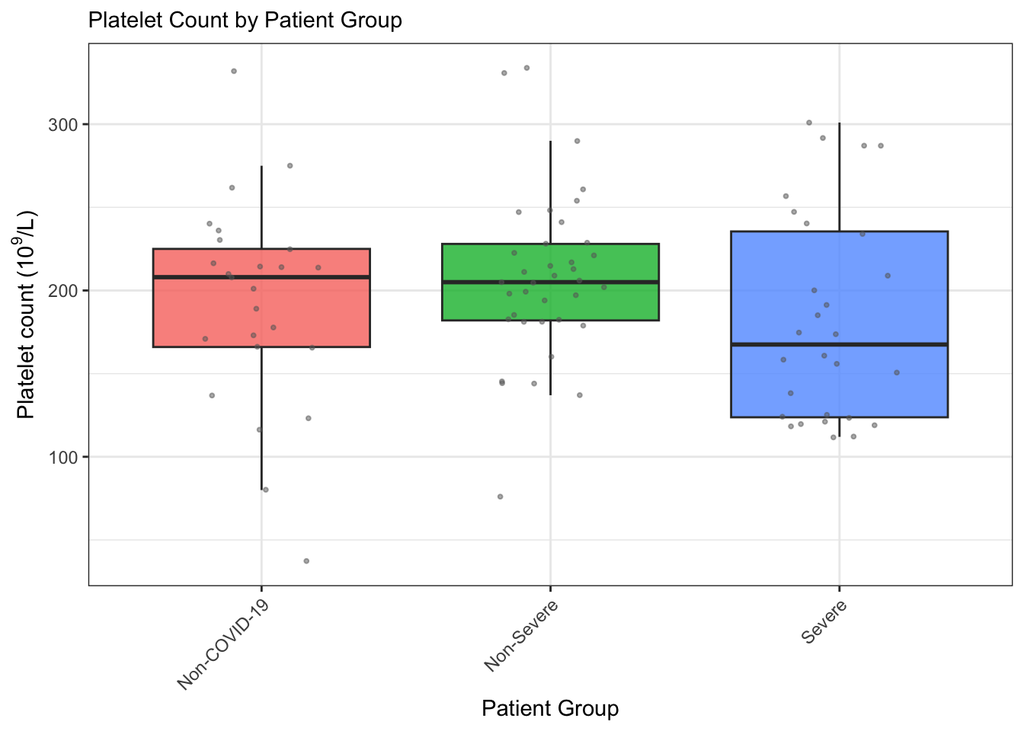

```r
#install.packages('ggplot2')
#install.packages('janitor')
library(ggplot2)
library(janitor)
library(dbplyr)
data <- clean_names(data)
toy <- data %>% select(patient_id_a, group_d, platelet_count_109_l)
toy$group_d <- as.factor(toy$group_d)

data_clean <- data %>%
  filter(group_d %in% c(1, 2, 3)) %>%   # remove NA and unwanted groups
  mutate(
    group_d = factor(
      group_d,
      levels = c(1, 2, 3),
      labels = c("Non-COVID-19", "Non-Severe", "Severe")
    )
  )

ggplot(data_clean,
       aes(x = group_d,
           y = platelet_count_109_l,
           fill = group_d)) +
  geom_boxplot(outlier.shape = NA, alpha = 0.8) +
  geom_jitter(
    width = 0.2,
    size = 0.7,
    alpha = 0.5,
    color = "grey40"
  ) +
  labs(
    title = "Platelet Count by Patient Group",
    x = "Patient Group",
    y = expression("Platelet count ("*10^9*"/L)")
  ) +
  theme_bw() +
  theme(
    legend.position = "none",
    plot.title = element_text(size = 11),
    axis.text.x = element_text(angle = 45, hjust = 1)
  )
```

```r
library(tidyverse)
clinical_vars <- c(
  "wbc_count_109_l"= "White blood cell (WBC)",
  "lymphocyte_count_109_l" = "Lymphocyte",
  "monocyte_count_109_l" = "Monocyte",
  "platelet_count_109_l" = "Platelet",
  "crp_i_mg_l" = "C-reactive protein (CRP)",
  "alt_j_u_l" = "Alanine aminotransferase (ALT)",
  "ast_k_u_l" = "Aspartate aminotransferase (AST)",
  "ggt_l_u_l" = "Glutamyltransferase (GGT)",
  "tbil_m_mmol_l" = "Total bilirubin (TBIL)",
  "dbil_n_mmol_l" = "Direct bilirubin (DBIL)",
  "creatinine_mmol_l" = "Creatinine",
  "glucose_mmol_l" = "Glucose"
)

data_clean <- data %>%
  filter(group_d %in% c(1, 2, 3)) %>%
  mutate(
    group_d = factor(
      group_d,
      levels = c(1, 2, 3),
      labels = c("Non-COVID-19", "Non-Severe", "Severe")
    )
  ) %>%
  mutate(
    across(
      all_of(names(clinical_vars)), # Look at the names (snake_case)
      ~ as.numeric(str_trim(.))
    )
  )
```

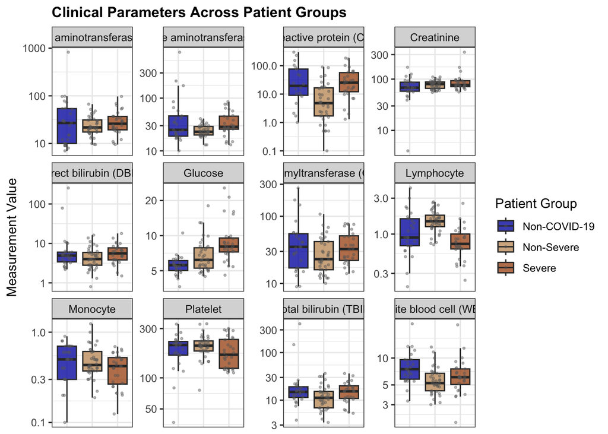

```r
data_long <- data_clean %>%
  pivot_longer(
    cols = all_of(names(clinical_vars)),
    names_to = "Parameter",
    values_to = "Value"
  ) %>%
  filter(!is.na(Value)) %>%
  mutate(
    Parameter = clinical_vars[Parameter]
  )

ggplot(data_long,
       aes(x = group_d,
           y = Value,
           fill = group_d)) +
  geom_boxplot(outlier.shape = NA, alpha = 0.8) +
  geom_jitter(
    width = 0.2,
    size = 0.6,
    alpha = 0.4,
    color = "grey40"
  ) +
  facet_wrap(~ Parameter, scales = "free_y", ncol = 4) +
  labs(
    title = "Clinical Parameters Across Patient Groups",
    x = NULL,
    y = "Measurement Value",
    fill = "Patient Group"
  ) +
  scale_y_log10() +
  scale_fill_manual(values = c("#0a23af", "#c89d6e", "#ad5c26")) +
  theme_bw() +
  theme(
    plot.title = element_text(size = 12, face = "bold"),
    strip.text = element_text(size = 9),
    axis.text.x = element_blank(),   # remove group labels
    axis.ticks.x = element_blank(),  # remove ticks
    legend.position = "right"        # show color guide
  )
```

## Exercise 2.2

Identify and handle outliers using an appropriate and well-justified method (e.g. removal, transformation, or robust statistics).

Reproduce Supplementary Figure 1 after outlier handling and discuss how and why the results change.

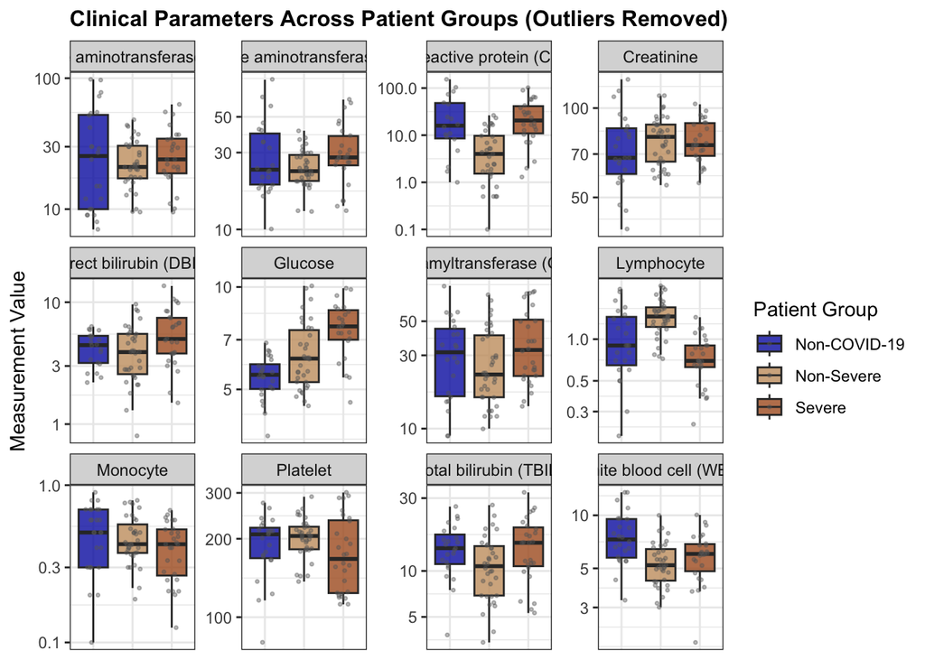

```r
data_no_outliers <- data_long %>%
  group_by(Parameter, group_d) %>%
  filter(
    Value >= quantile(Value, 0.25, na.rm = TRUE) -
             1.5 * IQR(Value, na.rm = TRUE),
    Value <= quantile(Value, 0.75, na.rm = TRUE) +
             1.5 * IQR(Value, na.rm = TRUE)
  ) %>%
  ungroup()


ggplot(data_no_outliers,
       aes(x = group_d,
           y = Value,
           fill = group_d)) +
  geom_boxplot(outlier.shape = NA, alpha = 0.8) +
  geom_jitter(
    width = 0.2,
    size = 0.6,
    alpha = 0.4,
    color = "grey40"
  ) +
  facet_wrap(~ Parameter, scales = "free_y", ncol = 4) +
  labs(
    title = "Clinical Parameters Across Patient Groups (Outliers Removed)",
    x = NULL,
    y = "Measurement Value",
    fill = "Patient Group"
  ) +
  scale_y_log10() +
  scale_fill_manual(values = c("#0a23af", "#c89d6e", "#ad5c26")) +
  theme_bw() +
  theme(
    plot.title = element_text(size = 12, face = "bold"),
    strip.text = element_text(size = 9),
    axis.text.x = element_blank(),   # remove group labels
    axis.ticks.x = element_blank(),  # remove ticks
    legend.position = "right"        # show color guide
  )
```